# Remote Work

Section 2: Data Exploration

Michael Foley

8/1/2021

```r
library(tidyverse)
library(ggtext)
library(janitor)
library(flextable)
library(patchwork)

buffer <- readRDS("./buffer.rds")
codebook <- readRDS("./codebook.rds")
```

My objective is to learn how the struggles with remote work differ among workers. “Not being able to unplug” is the largest reported struggle. “Difficulties with collaboration and communication” is second, followed by “Loneliness”, “Distractions at home”, and “Staying motivated”. “Being in a different timezone than teammates” was least reported struggle.

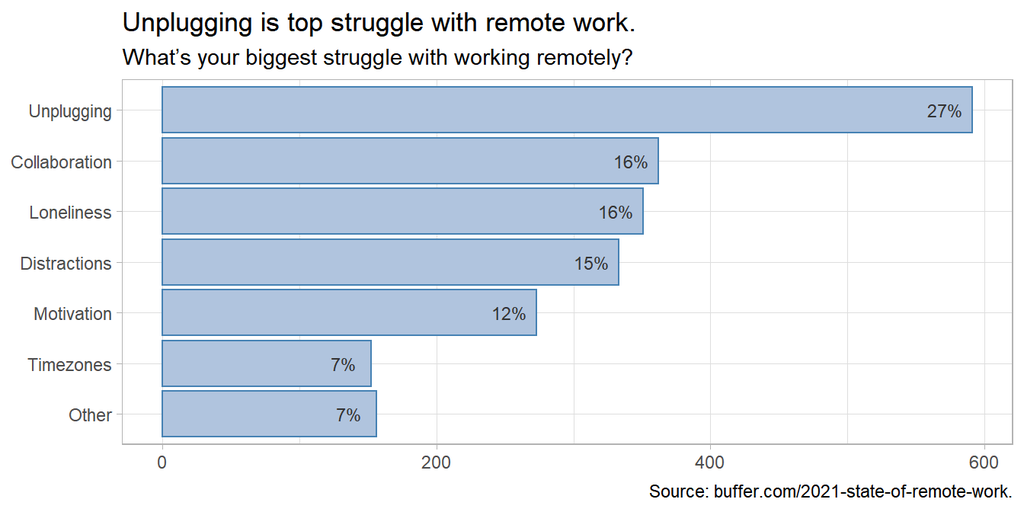

```r
buffer %>%
  count(struggle) %>%
  mutate(pct = n / sum(n),
         struggle = fct_reorder(struggle, pct),
         struggle = fct_relevel(struggle, "Other", after = 0)) %>%
  ggplot(aes(x = struggle, y = n)) +
  geom_col(fill = "lightsteelblue", color = "steelblue") +
  geom_text(aes(label = scales::percent(pct, accuracy = 1)),
            size = 3, nudge_y = -20, color = "#333333") +
  coord_flip() +
  theme_light() +
  labs(x = NULL, y = NULL,
       title = "Unplugging is top struggle with remote work.",
       subtitle = codebook %>% filter(item == "struggle") %>% pull(desc),
       caption = "Source: buffer.com/2021-state-of-remote-work.")
```

```r
plot_prop <- function(x, grp_var, grp_title) {
  grp_var <- ensym(grp_var)
  x %>%
    filter(struggle != "Other") %>%
    count(struggle, !!grp_var) %>%
    group_by(!!grp_var) %>%
    mutate(pct = n / sum(n)) %>%
    ggplot(aes(x = fct_rev(!!grp_var), y = pct)) +
    geom_col(fill = "lightsteelblue", color = "steelblue") +
    geom_text(aes(label = n), size = 3, nudge_y = -.03) +
    scale_y_continuous(labels = scales::percent_format()) +
    coord_flip() +
    theme_light() +
    theme(strip.background = element_rect(fill = "gray90"),
          strip.text = element_text(color = "steelblue")) +
    labs(title = grp_title,
         subtitle = codebook %>% filter(item == grp_var) %>% pull(desc),
         y = NULL, x = NULL, fill = NULL) +
    facet_wrap(facets = vars(struggle))
}
```

# Preference for Remote Work

The overwhelming majority of all survey respondents prefer to indefinitely continue remote work, at least some of the time. It’s important to keep this in context because we are looking at the struggles among workers who overwhelming think they are worth the benefits.

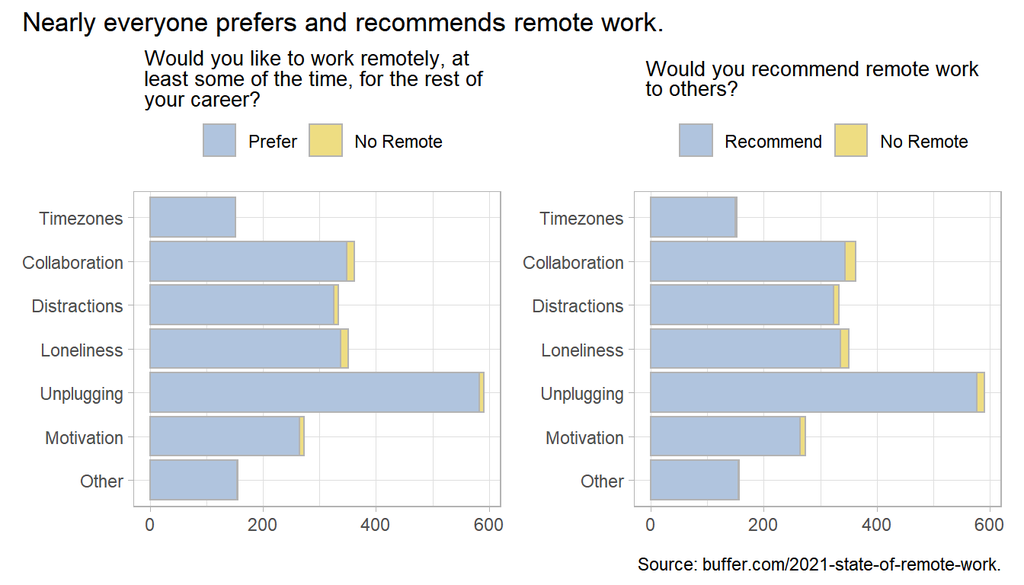

```r
p1 <- buffer %>%
  ggplot(aes(x = fct_rev(struggle), fill = prefer_remote)) +
  geom_bar(color = "gray70") +
  coord_flip() +
  theme_light() +
  scale_fill_manual(values = c("lightgoldenrod", "lightsteelblue")) +
  theme(legend.position = "top") +
  guides(fill = guide_legend(reverse=TRUE)) +
  labs(subtitle = codebook %>% filter(item == "prefer_remote") %>% pull(desc),
       y = NULL, x = NULL, fill = NULL) +
  theme(
    plot.subtitle = element_textbox_simple(
      size = 10,
      lineheight = 1,
      padding = margin(5.5, 5.5, 5.5, 5.5),
      margin = margin(0, 0, 5.5, 0),
      fill = "#FFFFFF"
    )
  )

p2 <- buffer %>%
  ggplot(aes(x = fct_rev(struggle), fill = recommend_remote)) +
  geom_bar(color = "gray70") +
  coord_flip() +
  theme_light() +
  scale_fill_manual(values = c("lightgoldenrod", "lightsteelblue")) +
  theme(legend.position = "top") +
  guides(fill = guide_legend(reverse=TRUE)) +
  labs(subtitle = codebook %>% filter(item == "recommend_remote") %>% pull(desc),
       y = NULL, x = NULL, fill = NULL) +
  theme(
    plot.subtitle = element_textbox_simple(
      size = 10,
      lineheight = 1,
      padding = margin(5.5, 5.5, 5.5, 5.5),
      margin = margin(0, 0, 5.5, 0),
      fill = "#FFFFFF"
    )
  )

p1 + p2 +
  plot_annotation(title = "Nearly everyone prefers and recommends remote work.",
                  caption = "Source: buffer.com/2021-state-of-remote-work.")
```

## Race

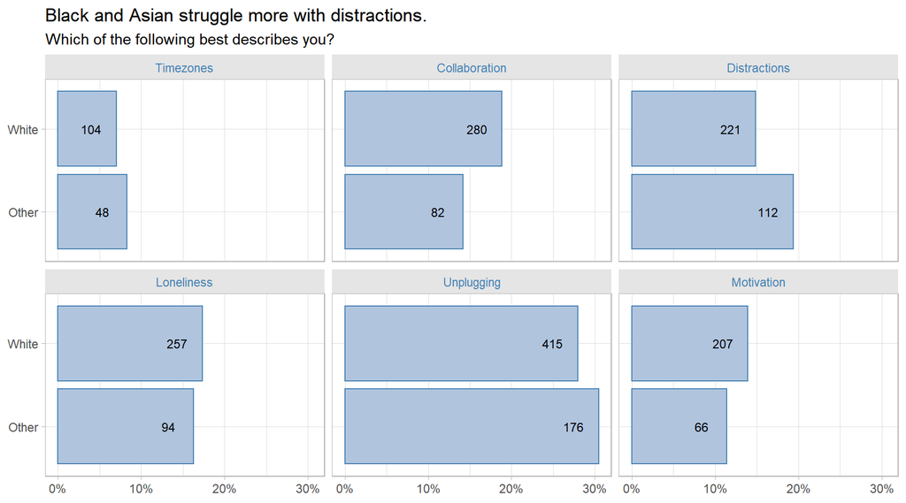

```r
buffer %>% plot_prop("race",
                     "Black and Asian struggle more with distractions.")
```

## Work Experience

New workers (less then six months) were more likely to cite struggling with motivation. After six months, workers struggled a great deal with loneliness, but with diminishing rate as work experience increased. Struggling to unplug was positively associated with experience.

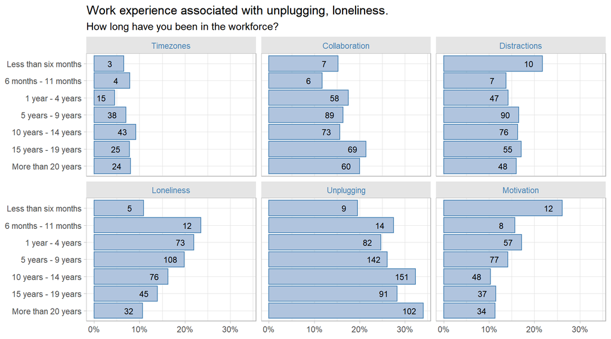

```r
buffer %>% plot_prop("work_exp",
                     "Work experience associated with unplugging, loneliness.")
```

## Remote Work Experience

Experience with remote work followed a similar pattern to overall work experience, except that the relationship with loneliness disappears.

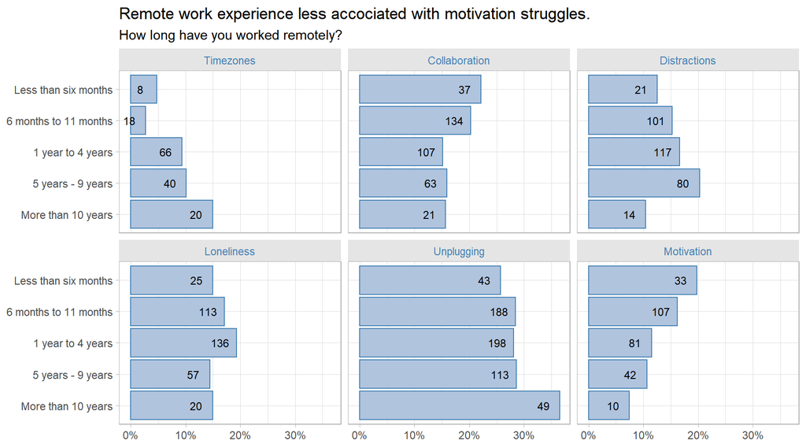

```r
buffer %>% plot_prop("remote_exp",
                     "Remote work experience less accociated with motivation struggles.")
```